# Munich in numbers

CU

10/6/2019

# Brief exploratory analysis

This is a brief EDA of Munich stats.

## Data

### source

Thanks to **Statistische Amt München** for making the data available on a monthly basis. They make way more data available, these are solely main KPIs. Source of data: http://www.mstatistik-muenchen.de/monatszahlenmonitoring/export/export.php. Official Data exploration portal: http://www.mstatistik-muenchen.de/monatszahlenmonitoring/atlas.html?indicator=i158&date=Jan&select=20,19&select2=JAHR&indicator2=i0. Data here is extracted from Excel, processed into data.frames and correlation charts

### raw

The raw data is a list of data-frames

```r
as.data.frame(lapply(dat, dim)) %>%
  rownames_to_column() %>%
  kable()
```

| rowname | INHALTSÜBERSICHT | ARBEITSMARKT | BAUEN | BEVÖLKERUNG | EINBÜRGERUNGEN | FEUERWEHR.MÜNCHEN | FLUGVERKEHR | FREIZEIT | KFZ.Bestand | KFZ.Neuzulassungen | KINOS | MUSEEN | ORCHESTER | SOZIALE.LEISTUNGEN | THEATER | TOURISMUS | VERKEHRSUNFÄLLE | WIRTSCHAFT | WITTERUNG | IMPRESSUM |
| --- | --- | --- | --- | --- | --- | --- | --- | --- | --- | --- | --- | --- | --- | --- | --- | --- | --- | --- | --- | --- |
| 1 | 288 | 2119 | 720 | 19109 | 660 | 1914 | 1880 | 1639 | 4984 | 2592 | 228 | 2068 | 1416 | 2055 | 4056 | 954 | 1596 | 4462 | 1638 | 13 |
| 2 | 7 | 9 | 9 | 9 | 9 | 9 | 9 | 9 | 9 | 9 | 9 | 9 | 9 | 9 | 9 | 9 | 9 | 9 | 9 | 1 |

### aggregated

We’ll now compress the **original disparated data** in one compact data.frame For that, we create dynamic column names and aggregate the monthly values The final result will be a large matrix (~300 columns) where each column represents a variable and the rows are the monthly values (20 yrs x 12 months)

```r
##########################
# looping through all the Excel sheets
dsFinal <- data.frame()
for (i in 1:length(names(dat))) {
  SECTIONNAME <- names(dat)[i]
  dtmp <- (dat[SECTIONNAME])[[1]]
  # if the current section has values in it
  if ('WERT' %in% names(dtmp)) {
    # creating dynamic column names and assign monthly values as cols
    dtmp_mo <- dtmp %>%
      select(MONATSZAHL, AUSPRAEGUNG, MONAT, WERT) %>%
      mutate(colname=paste(SECTIONNAME, MONATSZAHL, AUSPRAEGUNG, sep = " - ")) %>%
      select(MONAT, colname, WERT) %>%
      spread(MONAT, WERT)
    rownames(dtmp_mo) <- dtmp_mo$colname
    dtmp_mo$colname <- NULL
    # transpose monthly values to rows
    dtmp_mo <- t(dtmp_mo)
    # back from tibble to dataframe
    dtmp_mo <-as.data.frame(dtmp_mo)
    dtmp_mo$month <- rownames(dtmp_mo)

    if (nrow(dsFinal)==0){
      # if the final construct doesn't exist, simply create it
      dsFinal <- dtmp_mo
    } else {
      # if we have values in it already, merge them (full join)  using the month column
      dsFinal <- dtmp_mo %>%
        full_join(dsFinal, by = "month")
    }
  }
}
# cleanup
rm(dtmp, dtmp_mo, i, SECTIONNAME)

rownames(dsFinal) <- dsFinal$month
dsFinal$month <- NULL
dim(dsFinal)
```

```
## [1] 236 288
```

```r
# dsFinal[1:10,1:2] %>% kable()
# colMeans(dsFinal, na.rm = T) %>% kable()
# str(dsFinal)
##########################
```

# General Trends (monthly)

## Cinema visitors

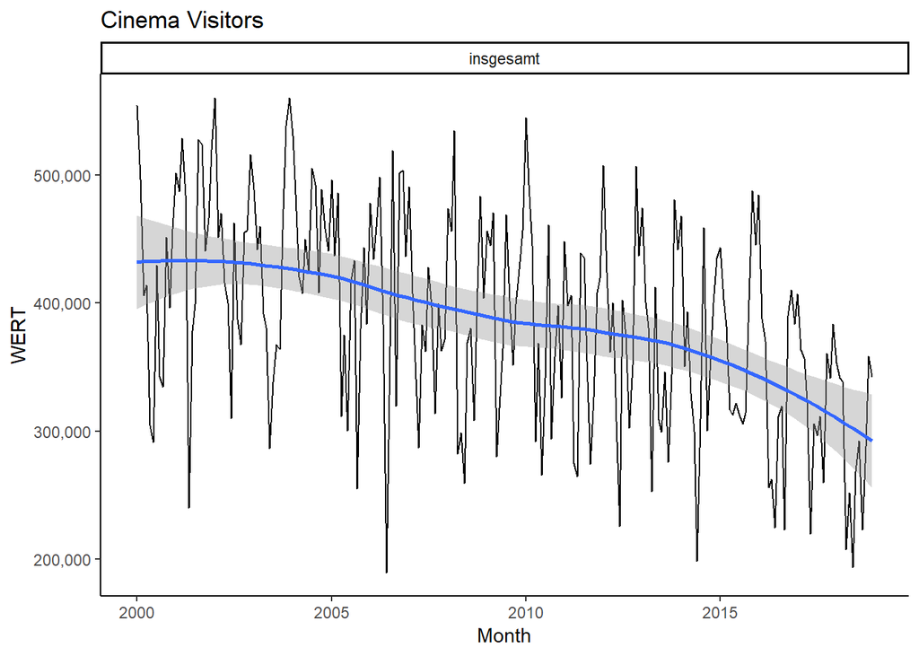

```r
##########################
# exploratory charts
dat$KINOS %>%
  mutate(Month = as.Date(paste0(MONAT,'01'), format = '%Y%m%d')) %>%
  ggplot(., aes(x=Month, y = WERT, group=AUSPRAEGUNG)) +
    geom_line() +
    facet_wrap(~AUSPRAEGUNG) +
    theme_classic()+
    geom_smooth() + scale_y_continuous(labels = scales::comma) + ggtitle("Cinema Visitors")
```

## weather trends

### Sun & temperature

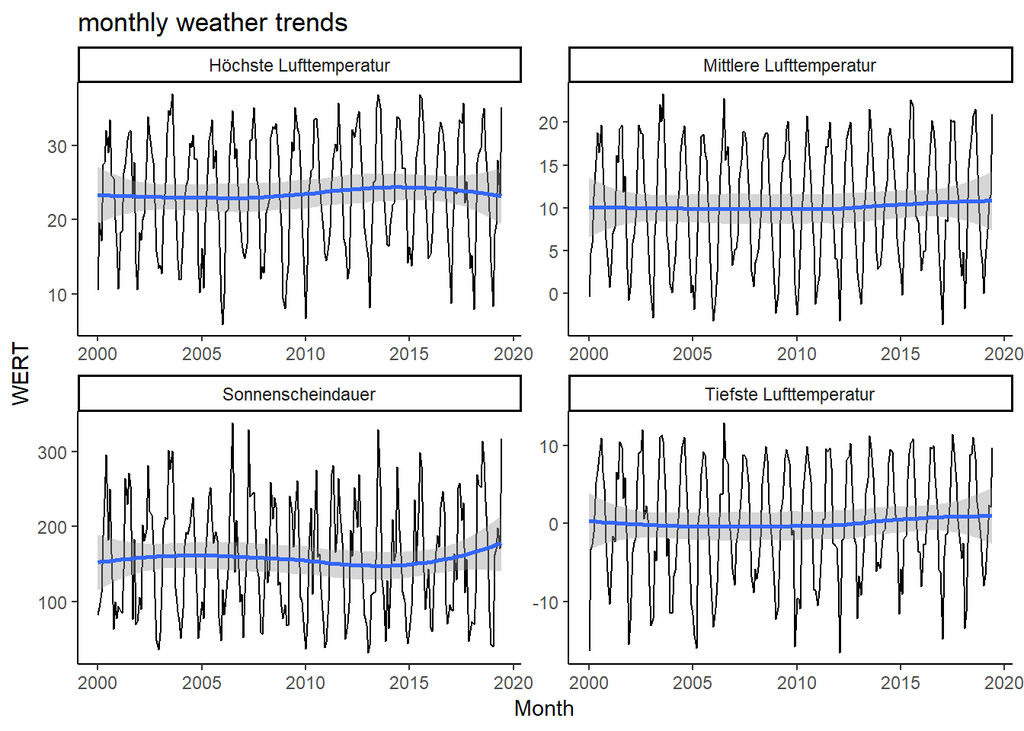

```r
dat$WITTERUNG %>%
  filter(MONATSZAHL %in% c("Sonnenschein", "Lufttemperatur")) %>%
  mutate(Month = as.Date(paste0(MONAT,'01'), format = '%Y%m%d')) %>%
  ggplot(., aes(x=Month, y = WERT, group=AUSPRAEGUNG)) +
  geom_line() +
  facet_wrap(~AUSPRAEGUNG, scales = "free") +
  theme_classic()+
  geom_smooth() + scale_y_continuous(labels = scales::comma) + ggtitle("monthly weather trends")
```

### Rain

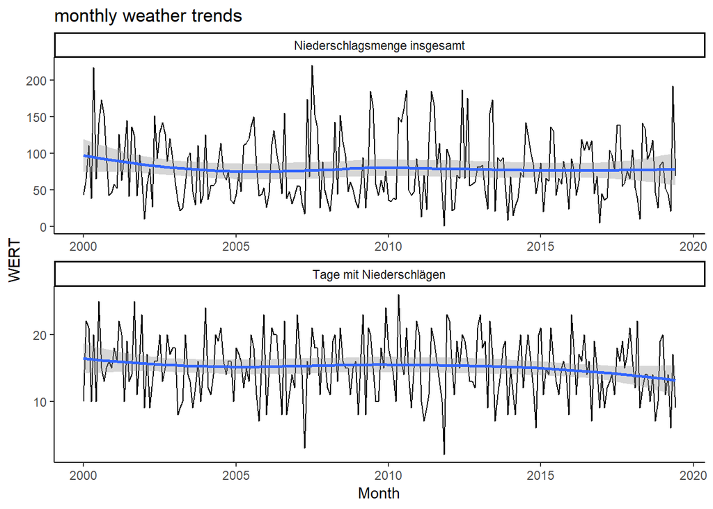

```r
dat$WITTERUNG %>%
  filter(MONATSZAHL %in% c("Niederschlag")) %>%
  mutate(Month = as.Date(paste0(MONAT,'01'), format = '%Y%m%d')) %>%
  ggplot(., aes(x=Month, y = WERT, group=AUSPRAEGUNG)) +
  geom_line() +
  facet_wrap(~AUSPRAEGUNG, scales = "free", nrow=2) +
  theme_classic()+
  geom_smooth() + scale_y_continuous(labels = scales::comma) + ggtitle("monthly weather trends")
```

## Tourists

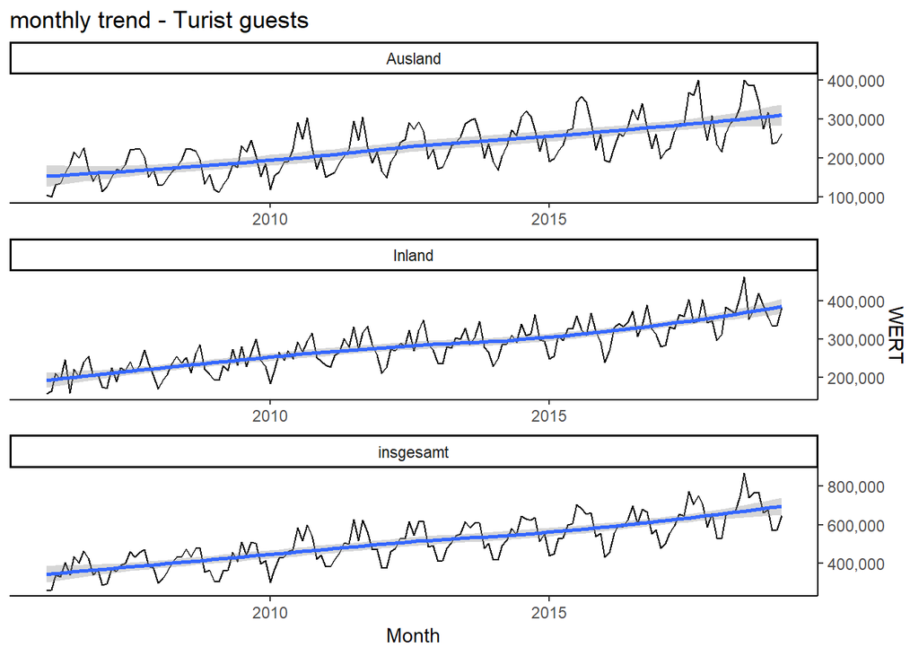

```r
dat$TOURISMUS %>%
  filter(MONATSZAHL %in% c("Gäste")) %>%
  mutate(Month = as.Date(paste0(MONAT,'01'), format = '%Y%m%d')) %>%
  ggplot(., aes(x=Month, y = WERT, group=AUSPRAEGUNG)) +
  geom_line() +
  facet_wrap(~AUSPRAEGUNG, scales = "free", nrow=3) +
  theme_classic()+
  geom_smooth() + scale_y_continuous(position = "right", labels = scales::comma) + ggtitle("monthly trend - Turist guests")
```

## Population

### German population 2010-today

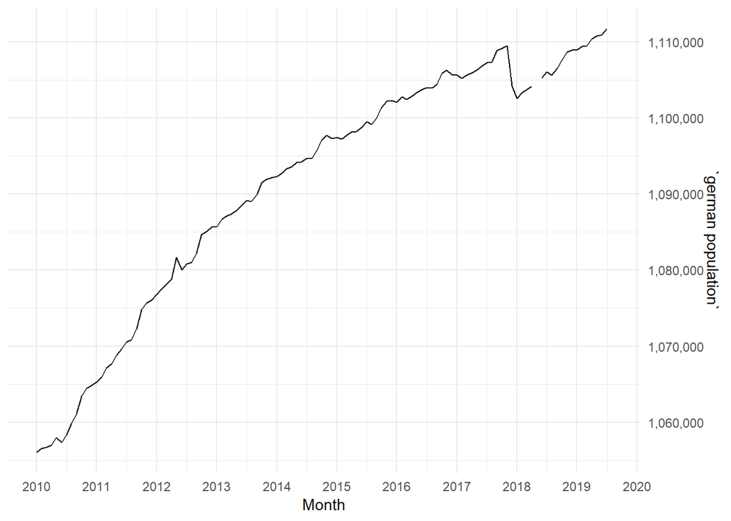

```r
dsFinal %>%
  rownames_to_column() %>%
  select(rowname, `german population` =  `BEVÖLKERUNG - Geschlecht und Staatsangehörigkeit - Deutsche insgesamt`) %>%
  mutate(Month = as.Date(paste0(rowname,'01'), format = '%Y%m%d')) %>%
  filter(Month>='2010-01-01') %>%
  ggplot(aes(x = Month))  +
    geom_line(aes(y = `german population`)) +
    theme_minimal() +
    scale_x_date(date_breaks = "1 year", date_labels = "%Y") +
    scale_y_continuous(position = "right", labels = scales::comma)
```

### Foreigners 2010-today

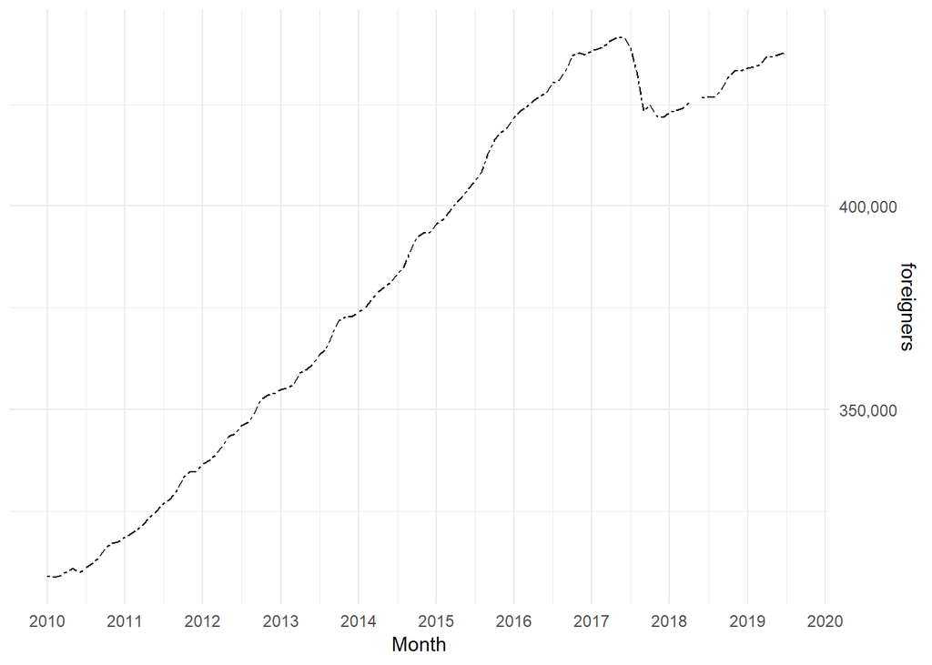

```r
dsFinal %>%
  rownames_to_column() %>%
  select(rowname, `foreigners` = `BEVÖLKERUNG - Geschlecht und Staatsangehörigkeit - Ausländer/innen insgesamt`) %>%
  mutate(Month = as.Date(paste0(rowname,'01'), format = '%Y%m%d')) %>%
  filter(Month>='2010-01-01') %>%
  ggplot(aes(x = Month))  +
    geom_line(aes(y = foreigners), linetype="twodash") +
    theme_minimal() +
    scale_x_date(date_breaks = "1 year", date_labels = "%Y") +
    scale_y_continuous(position = "right", labels = scales::comma)
```

### Inhabitants (all & gender)

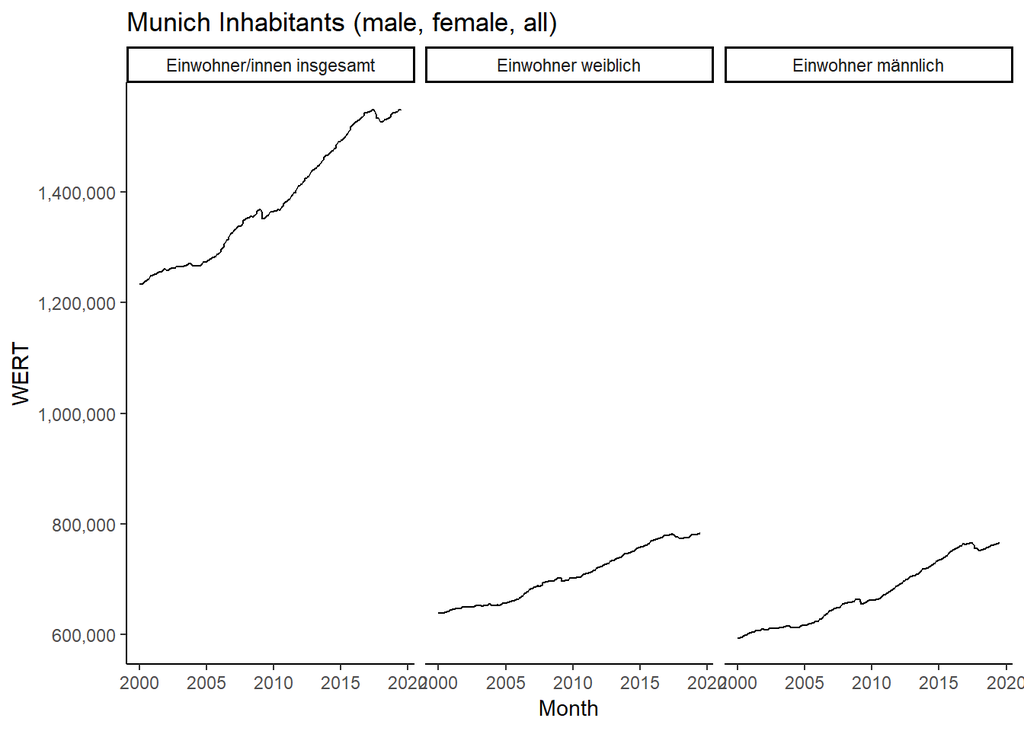

```r
dat$BEVÖLKERUNG %>%
  filter(MONATSZAHL %in% c("Geschlecht und Staatsangehörigkeit")) %>%
  filter(str_detect(AUSPRAEGUNG, 'Einwohner')) %>%
  mutate(Month = as.Date(paste0(MONAT,'01'), format = '%Y%m%d')) %>%
  arrange(-WERT) %>% # sort
  mutate_at(vars(AUSPRAEGUNG), funs(factor(., levels=unique(.)))) %>% # convert to factor
  ggplot(., aes(x=Month, y = WERT, group=AUSPRAEGUNG)) +
  geom_line() +
  facet_wrap(~AUSPRAEGUNG) +
  theme_classic()+
  scale_y_continuous(labels = scales::comma) + ggtitle("Munich Inhabitants (male, female, all)")
```

### German inhabitants (all & gender)

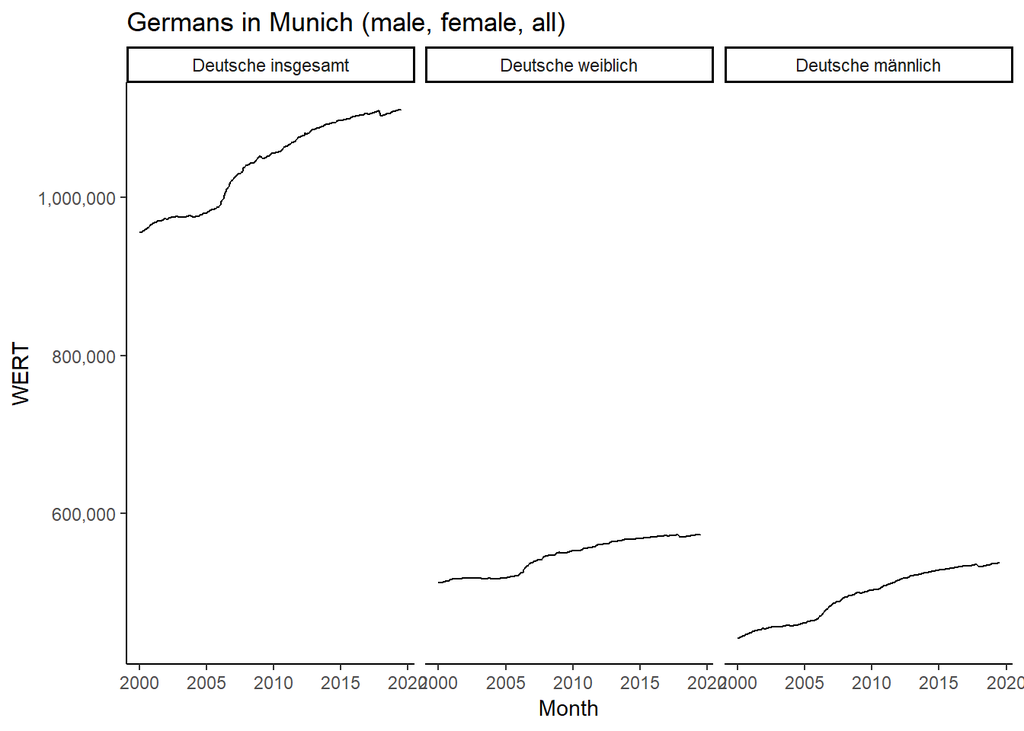

```r
dat$BEVÖLKERUNG %>%
  filter(MONATSZAHL %in% c("Geschlecht und Staatsangehörigkeit")) %>%
  filter(str_detect(AUSPRAEGUNG, 'Deutsche')) %>%
  mutate(Month = as.Date(paste0(MONAT,'01'), format = '%Y%m%d')) %>%
  arrange(-WERT) %>% # sort
  mutate_at(vars(AUSPRAEGUNG), funs(factor(., levels=unique(.)))) %>% # convert to factor
  ggplot(., aes(x=Month, y = WERT, group=AUSPRAEGUNG)) +
  geom_line() +
  facet_wrap(~AUSPRAEGUNG) +
  theme_classic()+
  scale_y_continuous(labels = scales::comma) + ggtitle("Germans in Munich (male, female, all)")
```

### Foreign inhabitants (all & gender)

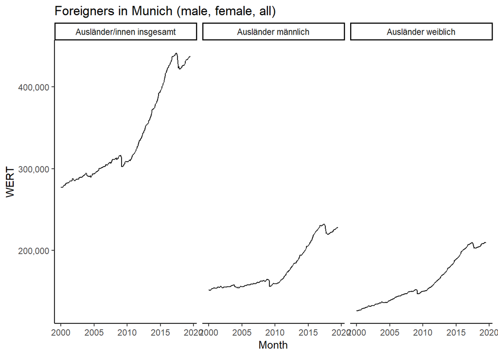

```r
dat$BEVÖLKERUNG %>%
  filter(MONATSZAHL %in% c("Geschlecht und Staatsangehörigkeit")) %>%
  filter(str_detect(AUSPRAEGUNG, 'Ausländer')) %>%
  mutate(Month = as.Date(paste0(MONAT,'01'), format = '%Y%m%d')) %>%
  arrange(-WERT) %>% # sort
  mutate_at(vars(AUSPRAEGUNG), funs(factor(., levels=unique(.)))) %>% # convert to factor
  ggplot(., aes(x=Month, y = WERT, group=AUSPRAEGUNG)) +
  geom_line() +
  facet_wrap(~AUSPRAEGUNG) +
  theme_classic()+
  scale_y_continuous(labels = scales::comma) + ggtitle("Foreigners in Munich (male, female, all)")
```

### Female share

#### among german nationals

```r
dsFinal %>%
  rownames_to_column() %>%
  mutate(
    year = substring(rowname, 0, 4),
    'german_female' = `BEVÖLKERUNG - Geschlecht und Staatsangehörigkeit - Deutsche weiblich`,
    'foreign_female' = `BEVÖLKERUNG - Geschlecht und Staatsangehörigkeit - Ausländer weiblich`,
    'all_german' = `BEVÖLKERUNG - Geschlecht und Staatsangehörigkeit - Deutsche insgesamt`,
    'all_female' = `BEVÖLKERUNG - Geschlecht und Staatsangehörigkeit - Einwohner weiblich`
   ) %>%
  select(year, german_female, foreign_female, all_german, all_female) %>%
  group_by(year) %>%
  summarize(
            german_female = round(mean(german_female, na.rm = TRUE),0),
            foreign_female = round(mean(foreign_female, na.rm = TRUE),0),
            all_german=round(mean(all_german, na.rm = TRUE),0),
            all_female=round(mean(all_female, na.rm = TRUE),0)
            ) %>%
  mutate(
    female_share_among_germans = round(german_female/all_german, 2),
    german_female_share = round(german_female/all_female, 2)
    ) %>%
  kable(format.args = list(decimal.mark = ".", big.mark = ",")) %>%
  kable_styling(bootstrap_options = c("striped", "hover", "condensed", "responsive"),
                fixed_thead = T) %>%
  add_header_above(c(" ", "in thousands" = 4, "percentages" = 2))
```

[output not shown]

#### among foreigners

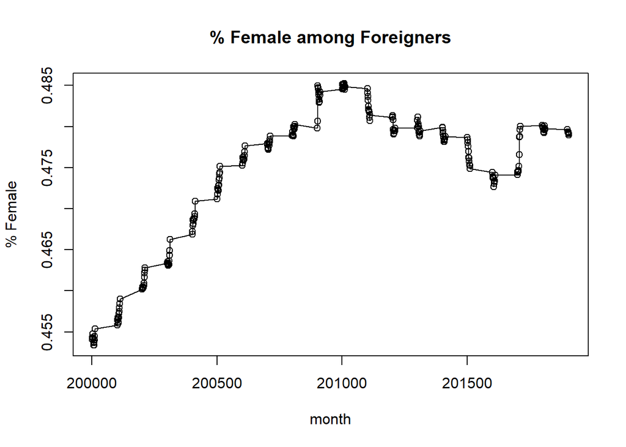

```r
plot(
    rownames(dsFinal)
    , dsFinal$`BEVÖLKERUNG - Geschlecht und Staatsangehörigkeit - Ausländer weiblich`  / dsFinal$`BEVÖLKERUNG - Geschlecht und Staatsangehörigkeit - Ausländer/innen insgesamt`
    , xlab = "month"
    , ylab = "% Female"
     , main="% Female among Foreigners",
    type="o")
```

### Family status

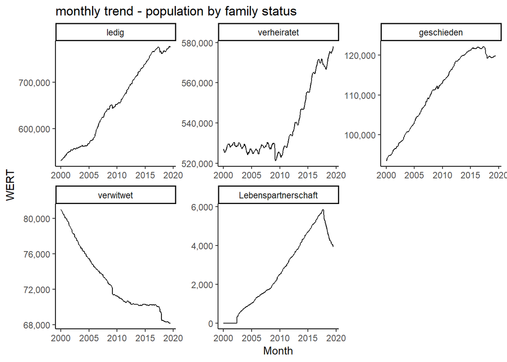

```r
dat$BEVÖLKERUNG %>%
  filter(MONATSZAHL %in% c("Familienstand")) %>%
  mutate(Month = as.Date(paste0(MONAT,'01'), format = '%Y%m%d')) %>%
  arrange(-WERT) %>% # sort
  mutate_at(vars(AUSPRAEGUNG), funs(factor(., levels=unique(.)))) %>% # convert to factor
  ggplot(., aes(x=Month, y = WERT, group=AUSPRAEGUNG)) +
  geom_line() +
  facet_wrap(~AUSPRAEGUNG, scales = "free") +
  theme_classic()+
  scale_y_continuous(labels = scales::comma) + ggtitle("monthly trend - population by family status")
```

```r
#ggsave("monthly trend - population by family status.png", dpi=400, dev='png', height=4, width=5, units="in", scale = 2)
```

### Age groups

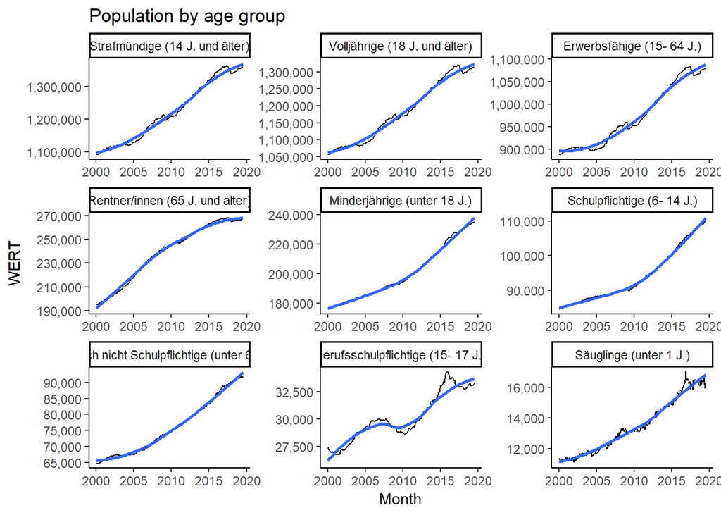

```r
dat$BEVÖLKERUNG %>%
    filter(MONATSZAHL %in% c("Altersgruppen")) %>%
    mutate(Month = as.Date(paste0(MONAT,'01'), format = '%Y%m%d')) %>%
    arrange(-WERT) %>% # sort
    mutate_at(vars(AUSPRAEGUNG), funs(factor(., levels=unique(.)))) %>% # convert to factor
    ggplot(., aes(x=Month, y = WERT, group=AUSPRAEGUNG)) +
    geom_line() +
    facet_wrap(~AUSPRAEGUNG, scales = "free") +
    theme_classic()+
    geom_smooth() + scale_y_continuous(labels = scales::comma) + ggtitle("Population by age group")
```

## Religion

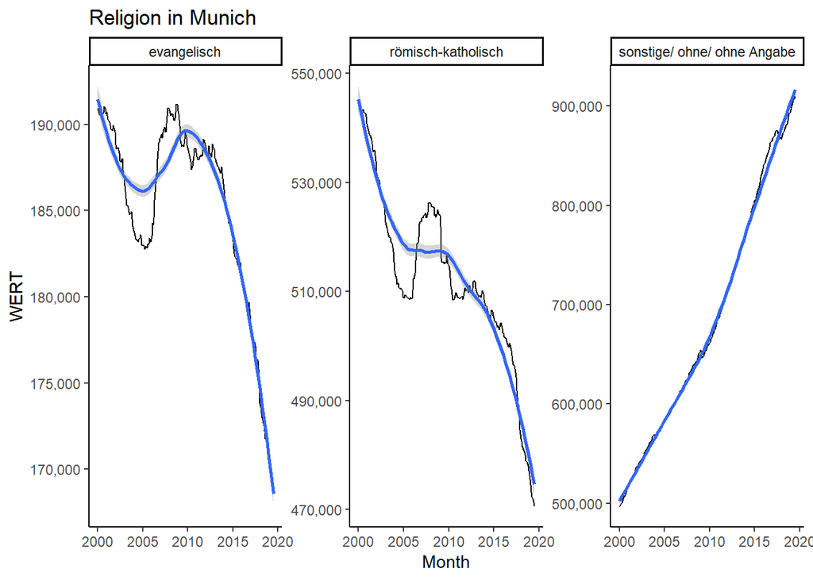

```r
dat$BEVÖLKERUNG %>%
    filter(MONATSZAHL %in% c("Religionszugehörigkeit")) %>%
    mutate(Month = as.Date(paste0(MONAT,'01'), format = '%Y%m%d')) %>%
    ggplot(., aes(x=Month, y = WERT, group=AUSPRAEGUNG)) +
    geom_line() +
    facet_wrap(~AUSPRAEGUNG, scales = "free") +
    theme_classic()+
    geom_smooth() + scale_y_continuous(labels = scales::comma) + ggtitle("Religion in Munich")
```

## Unemployment (gender & nationality)

### absolute numbers

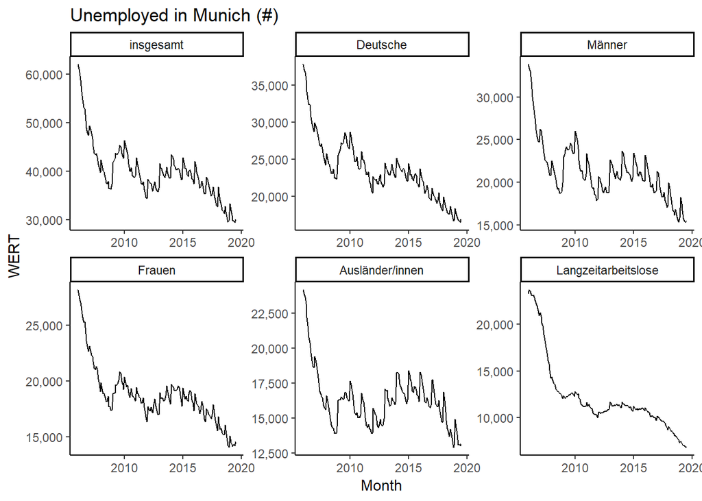

```r
dat$ARBEITSMARKT %>%
  filter(MONATSZAHL %in% c("Arbeitslose")) %>%
  filter(AUSPRAEGUNG %in% c("insgesamt","Frauen","Männer","Deutsche","Deutsche", "Ausländer/innen", "Langzeitarbeitslose")) %>%
  mutate(Month = as.Date(paste0(MONAT,'01'), format = '%Y%m%d')) %>%
  arrange(-WERT) %>% # sort
  mutate_at(vars(AUSPRAEGUNG), funs(factor(., levels=unique(.)))) %>% # convert to factor
  ggplot(., aes(x=Month, y = WERT, group=AUSPRAEGUNG)) +
  geom_line() +
  facet_wrap(~AUSPRAEGUNG, scales = "free") +
  theme_classic()+
  scale_y_continuous(labels = scales::comma) + ggtitle("Unemployed in Munich (#)")
```

### as percentages

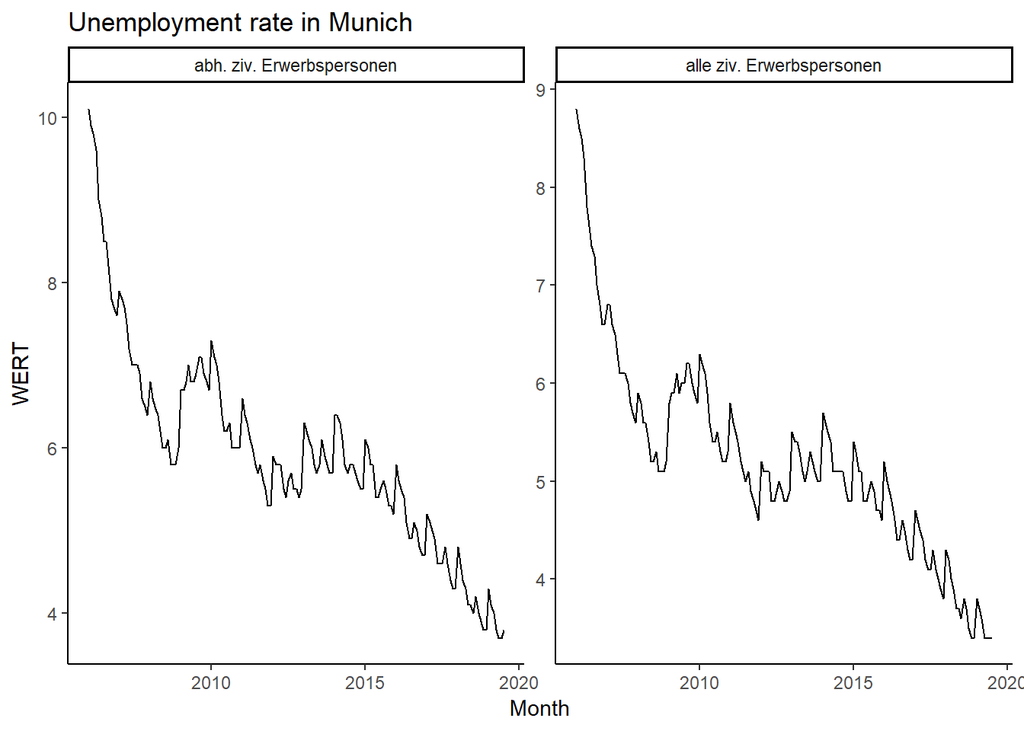

```r
dat$ARBEITSMARKT %>%
  filter(MONATSZAHL %in% c("Arbeitslosenquote")) %>%
  filter(AUSPRAEGUNG %in% c("abh. ziv. Erwerbspersonen", "alle ziv. Erwerbspersonen")) %>%
  mutate(Month = as.Date(paste0(MONAT,'01'), format = '%Y%m%d')) %>%
  arrange(-WERT) %>% # sort
  mutate_at(vars(AUSPRAEGUNG), funs(factor(., levels=unique(.)))) %>% # convert to factor
  ggplot(., aes(x=Month, y = WERT, group=AUSPRAEGUNG)) +
  geom_line() +
  facet_wrap(~AUSPRAEGUNG, scales = "free") +
  theme_classic()+
  scale_y_continuous(labels = scales::comma) + ggtitle("Unemployment rate in Munich")
```

# Counting NAs (missing data)

```r
##########################
# count NAs
# absolute number of missing values
nasCount <- dsFinal %>%
  summarise_all(funs(sum(is.na(.))))
# relative count
nasCount <- nasCount/nrow(dsFinal)
# transpose percent of missing values
nasCount <- as.data.frame(t(nasCount))
nasCount$field <- rownames(nasCount)
names(nasCount) <- c('NAs_proc', 'field_name')
# done
head(nasCount) %>% kable()
```

|  | NAs_proc | field_name |
| --- | --- | --- |
| WITTERUNG - Luftfeuchtigkeit - Mittlere relative Luftfeuchtigkeit | 0.0084746 | WITTERUNG - Luftfeuchtigkeit - Mittlere relative Luftfeuchtigkeit |
| WITTERUNG - Lufttemperatur - Höchste Lufttemperatur | 0.0084746 | WITTERUNG - Lufttemperatur - Höchste Lufttemperatur |
| WITTERUNG - Lufttemperatur - Mittlere Lufttemperatur | 0.0084746 | WITTERUNG - Lufttemperatur - Mittlere Lufttemperatur |
| WITTERUNG - Lufttemperatur - Tiefste Lufttemperatur | 0.0084746 | WITTERUNG - Lufttemperatur - Tiefste Lufttemperatur |
| WITTERUNG - Niederschlag - Niederschlagsmenge insgesamt | 0.0084746 | WITTERUNG - Niederschlag - Niederschlagsmenge insgesamt |
| WITTERUNG - Niederschlag - Tage mit Niederschlägen | 0.0084746 | WITTERUNG - Niederschlag - Tage mit Niederschlägen |

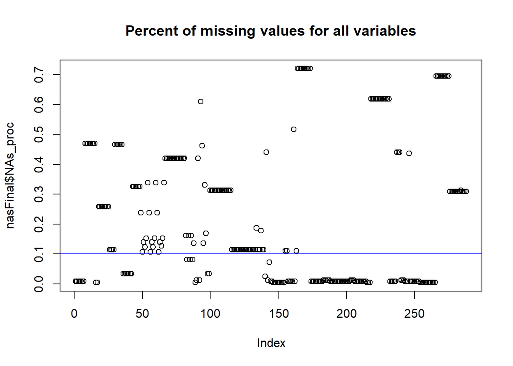

```r
nasFinal <- data.frame("field_name" =  nasCount$field_name, "NAs_proc" = nasCount$NAs_proc)
plot(nasFinal$NAs_proc, main="Percent of missing values for all variables")
abline(h=0.1, col="blue")
```

```r
rm(nasCount)
##########################
```

we will **cut all variables filled below 10%** (so all above the blue line).

# Explore correlations

## simple use of cor()

```r
##########################
# explore correlation
dsCor <- cor(dsFinal, use = "pairwise.complete.obs")

dsCor[1:5, 1:5]
```

```
##                                                                   WITTERUNG - Luftfeuchtigkeit - Mittlere relative Luftfeuchtigkeit
## WITTERUNG - Luftfeuchtigkeit - Mittlere relative Luftfeuchtigkeit                                                        1.00000000
## WITTERUNG - Lufttemperatur - Höchste Lufttemperatur                                                                     -0.64793440
## WITTERUNG - Lufttemperatur - Mittlere Lufttemperatur                                                                    -0.62228448
## WITTERUNG - Lufttemperatur - Tiefste Lufttemperatur                                                                     -0.51313290
## WITTERUNG - Niederschlag - Niederschlagsmenge insgesamt                                                                 -0.08243451
##                                                                   WITTERUNG - Lufttemperatur - Höchste Lufttemperatur
## WITTERUNG - Luftfeuchtigkeit - Mittlere relative Luftfeuchtigkeit                                          -0.6479344
## WITTERUNG - Lufttemperatur - Höchste Lufttemperatur                                                         1.0000000
## WITTERUNG - Lufttemperatur - Mittlere Lufttemperatur                                                        0.9586386
## WITTERUNG - Lufttemperatur - Tiefste Lufttemperatur                                                         0.9037555
## WITTERUNG - Niederschlag - Niederschlagsmenge insgesamt                                                     0.4353042
##                                                                   WITTERUNG - Lufttemperatur - Mittlere Lufttemperatur
## WITTERUNG - Luftfeuchtigkeit - Mittlere relative Luftfeuchtigkeit                                           -0.6222845
## WITTERUNG - Lufttemperatur - Höchste Lufttemperatur                                                          0.9586386
## WITTERUNG - Lufttemperatur - Mittlere Lufttemperatur                                                         1.0000000
## WITTERUNG - Lufttemperatur - Tiefste Lufttemperatur                                                          0.9581775
## WITTERUNG - Niederschlag - Niederschlagsmenge insgesamt                                                      0.4822358
##                                                                   WITTERUNG - Lufttemperatur - Tiefste Lufttemperatur
## WITTERUNG - Luftfeuchtigkeit - Mittlere relative Luftfeuchtigkeit                                          -0.5131329
## WITTERUNG - Lufttemperatur - Höchste Lufttemperatur                                                         0.9037555
## WITTERUNG - Lufttemperatur - Mittlere Lufttemperatur                                                        0.9581775
## WITTERUNG - Lufttemperatur - Tiefste Lufttemperatur                                                         1.0000000
## WITTERUNG - Niederschlag - Niederschlagsmenge insgesamt                                                     0.5078810
##                                                                   WITTERUNG - Niederschlag - Niederschlagsmenge insgesamt
## WITTERUNG - Luftfeuchtigkeit - Mittlere relative Luftfeuchtigkeit                                             -0.08243451
## WITTERUNG - Lufttemperatur - Höchste Lufttemperatur                                                            0.43530416
## WITTERUNG - Lufttemperatur - Mittlere Lufttemperatur                                                           0.48223577
## WITTERUNG - Lufttemperatur - Tiefste Lufttemperatur                                                            0.50788102
## WITTERUNG - Niederschlag - Niederschlagsmenge insgesamt                                                        1.00000000
```

```r
# explore correlations with R https://drsimonj.svbtle.com/exploring-correlations-in-r-with-corrr
diag(dsCor) <- NA
col_has_over_90 <- apply(dsCor, 2, function(x) any(x > .9))

length(col_has_over_90)
```

```
## [1] 288
```

```r
#( dsCor[,col_has_over_90] )
```

## the correlate package

```r
library(corrr)
correlate(dsFinal, use = "pairwise.complete.obs")
```

```
##
## Correlation method: 'pearson'
## Missing treated using: 'pairwise.complete.obs'
```

[output not shown]

[output cut: 58 more lines]

[output not shown]

```r
# dsFinal %>%
#   correlate(use = "pairwise.complete.obs") %>%
#   focus(3:5, mirror = TRUE) %>%
#   network_plot()

# above 98% pearson correlation
dsFinal %>%
  correlate(use = "pairwise.complete.obs") %>%
  stretch() %>%
  filter(abs(r)>0.98) %>%
  head(20)
```

```
##
## Correlation method: 'pearson'
## Missing treated using: 'pairwise.complete.obs'
```

```
## # A tibble: 20 x 3
##    x                              y                                       r
##    <chr>                          <chr>                               <dbl>
##  1 WIRTSCHAFT - Handwerksbetrieb~ WIRTSCHAFT - Handwerksbetriebe - ~  0.991
##  2 WIRTSCHAFT - Handwerksbetrieb~ BEVÖLKERUNG - Haushalte nach Kind~ -0.982
##  3 WIRTSCHAFT - Handwerksbetrieb~ WIRTSCHAFT - Handwerksbetriebe - ~  0.991
##  4 WIRTSCHAFT - Handwerksbetrieb~ WIRTSCHAFT - Handwerksbetriebe - ~  0.990
##  5 WIRTSCHAFT - Handwerksbetrieb~ SOZIALE LEISTUNGEN - Empfänger na~  0.981
##  6 WIRTSCHAFT - Handwerksbetrieb~ SOZIALE LEISTUNGEN - Empfänger na~  0.982
##  7 WIRTSCHAFT - Handwerksbetrieb~ SOZIALE LEISTUNGEN - Grundsicheru~  0.984
##  8 WIRTSCHAFT - Handwerksbetrieb~ SOZIALE LEISTUNGEN - Grundsicheru~  0.982
##  9 WIRTSCHAFT - Handwerksbetrieb~ SOZIALE LEISTUNGEN - Grundsicheru~  0.984
## 10 WIRTSCHAFT - Handwerksbetrieb~ KFZ-Bestand - Pkw-Kraftstoffarten~  0.981
## 11 WIRTSCHAFT - Handwerksbetrieb~ BEVÖLKERUNG - EU-Nationalitäten -~  0.985
## 12 WIRTSCHAFT - Handwerksbetrieb~ BEVÖLKERUNG - Familienstand - led~  0.980
## 13 WIRTSCHAFT - Handwerksbetrieb~ BEVÖLKERUNG - Geschlecht und Staa~  0.981
## 14 WIRTSCHAFT - Handwerksbetrieb~ BEVÖLKERUNG - Geschlecht und Staa~  0.981
## 15 WIRTSCHAFT - Handwerksbetrieb~ BEVÖLKERUNG - Nicht-EU-Nationalit~ -0.982
## 16 WIRTSCHAFT - Handwerksbetrieb~ BEVÖLKERUNG - Religionszugehörigk~  0.981
## 17 WIRTSCHAFT - Handwerksbetrieb~ WIRTSCHAFT - Handwerksbetriebe - ~  0.990
## 18 WIRTSCHAFT - Verarbeitendes G~ WIRTSCHAFT - Verarbeitendes Gewer~  0.986
## 19 WIRTSCHAFT - Verarbeitendes G~ WIRTSCHAFT - Verarbeitendes Gewer~  0.986
## 20 VERKEHRSUNFÄLLE - Verkehrsunf~ VERKEHRSUNFÄLLE - Verkehrsunfälle~  0.981
```

```r
# how many does each correlate with
dsFinal %>%
  correlate(use = "pairwise.complete.obs") %>%
  stretch() %>%
  filter(abs(r)>0.98) %>%
  group_by(x) %>%
  count() %>%
  arrange(-n) %>%
  head(20)
```

```
##
## Correlation method: 'pearson'
## Missing treated using: 'pairwise.complete.obs'
```

```
## # A tibble: 20 x 2
## # Groups:   x [20]
##    x                                                                      n
##    <chr>                                                              <int>
##  1 BEVÖLKERUNG - Familienstand - ledig                                   29
##  2 BEVÖLKERUNG - Religionszugehörigkeit - sonstige/ ohne/ ohne Angabe    29
##  3 BEVÖLKERUNG - Geschlecht und Staatsangehörigkeit - Ausländer weib~    28
##  4 BEVÖLKERUNG - Altersgruppen - Minderjährige (unter 18 J.)             27
##  5 BEVÖLKERUNG - EU-Nationalitäten - Bulgarien                           27
##  6 BEVÖLKERUNG - Geschlecht und Staatsangehörigkeit - Einwohner/inne~    27
##  7 BEVÖLKERUNG - Geschlecht und Staatsangehörigkeit - Einwohner weib~    26
##  8 BEVÖLKERUNG - Altersgruppen - Noch nicht Schulpflichtige (unter 6~    25
##  9 SOZIALE LEISTUNGEN - Grundsicherung im Alter und bei Erwerbsminde~    25
## 10 SOZIALE LEISTUNGEN - Grundsicherung im Alter und bei Erwerbsminde~    24
## 11 BEVÖLKERUNG - Altersgruppen - Strafmündige (14 J. und älter)          23
## 12 BEVÖLKERUNG - Geschlecht und Staatsangehörigkeit - Einwohner männ~    23
## 13 SOZIALE LEISTUNGEN - Grundsicherung im Alter und bei Erwerbsminde~    23
## 14 BEVÖLKERUNG - Altersgruppen - Erwerbsfähige (15- 64 J.)               22
## 15 BEVÖLKERUNG - Altersgruppen - Volljährige (18 J. und älter)           22
## 16 BEVÖLKERUNG - Haushalte nach Nationengruppe - deutsch - ausländis~    22
## 17 BEVÖLKERUNG - Altersgruppen - Schulpflichtige (6- 14 J.)              21
## 18 BEVÖLKERUNG - Haushalte nach Kinderzahl - mit 1 Kind                  21
## 19 BEVÖLKERUNG - Kontinente - Amerika                                    21
## 20 SOZIALE LEISTUNGEN - Empfänger nach SGB XII - Männer                  21
```

```r
# split the correlated variables by section/subsections
dsFinal %>%
  correlate(use = "pairwise.complete.obs") %>%
  stretch() %>%
  filter(abs(r)>0.98) %>%
  mutate(x_field = x, y_field = y) %>%
  separate(x, into = c("x_sec", "x_subsection", "x_subsubsection"), sep = " - ") %>%
  separate(y, into = c("y_sec", "y_subsection", "y_subsubsection"), sep = " - ") %>%
  filter(x_sec!=y_sec)-> dsAgg
```

```
##
## Correlation method: 'pearson'
## Missing treated using: 'pairwise.complete.obs'
```

```r
# main correlated sections
( table(dsAgg$x_sec, dsAgg$y_sec) )
```

```
##
##                      BEVÖLKERUNG KFZ-Bestand SOZIALE LEISTUNGEN WIRTSCHAFT
##   BEVÖLKERUNG                  0          33                 78          7
##   KFZ-Bestand                 33           0                  8          1
##   SOZIALE LEISTUNGEN          78           8                  0          5
##   WIRTSCHAFT                   7           1                  5          0
```

```r
# dsFinal %>%
#   correlate(use = "pairwise.complete.obs") %>%
#   network_plot(min_cor = 0.98)



dsAgg %>%
  inner_join(nasFinal, by = c("x_field"="field_name")) %>%
  filter(NAs_proc <0.1) %>%
  select(x_field, y_field, r, NAs_proc) -> dsAggFiltered
(dsAggFiltered)
```

```
## # A tibble: 108 x 4
##    x_field                      y_field                          r NAs_proc
##    <chr>                        <chr>                        <dbl>    <dbl>
##  1 BEVÖLKERUNG - Altersgruppen~ SOZIALE LEISTUNGEN - Grunds~ 0.982  0.00847
##  2 BEVÖLKERUNG - Altersgruppen~ SOZIALE LEISTUNGEN - Grunds~ 0.981  0.00847
##  3 BEVÖLKERUNG - Altersgruppen~ SOZIALE LEISTUNGEN - Empfän~ 0.991  0.00847
##  4 BEVÖLKERUNG - Altersgruppen~ SOZIALE LEISTUNGEN - Empfän~ 0.981  0.00847
##  5 BEVÖLKERUNG - Altersgruppen~ SOZIALE LEISTUNGEN - Grunds~ 0.990  0.00847
##  6 BEVÖLKERUNG - Altersgruppen~ KFZ-Bestand - Fahrzeugtypen~ 0.985  0.00847
##  7 BEVÖLKERUNG - Altersgruppen~ SOZIALE LEISTUNGEN - Empfän~ 0.992  0.00847
##  8 BEVÖLKERUNG - Altersgruppen~ SOZIALE LEISTUNGEN - Empfän~ 0.981  0.00847
##  9 BEVÖLKERUNG - Altersgruppen~ SOZIALE LEISTUNGEN - Grunds~ 0.989  0.00847
## 10 BEVÖLKERUNG - Altersgruppen~ SOZIALE LEISTUNGEN - Empfän~ 0.981  0.00847
## # ... with 98 more rows
```

```r
##########################
```

# Next steps

- we look at cross-topic correlations (assuming that inter-topic correlations are logical: highest to lowest temperature f.e.)
- explore some highly correlated numbers
- **BEWARE OF CONFOUNDING VARIABLES**

## Highly Correlated variables

These are pure sample examples out of ~100

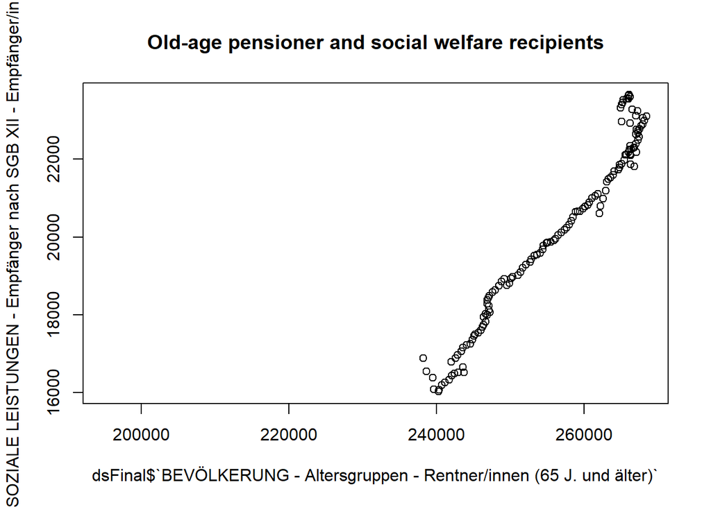

```r
plot(dsFinal$`BEVÖLKERUNG - Altersgruppen - Rentner/innen (65 J. und älter)`, dsFinal$`SOZIALE LEISTUNGEN - Empfänger nach SGB XII - Empfänger/innen insges.`,
     main="Old-age pensioner and social welfare recipients")
```

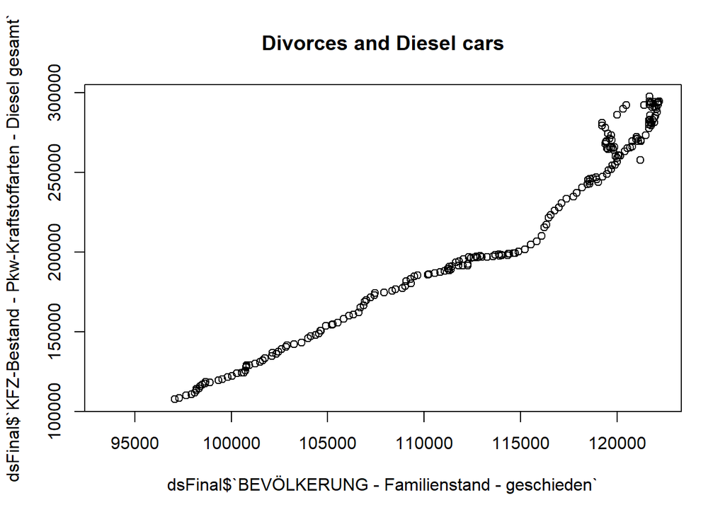

```r
plot(dsFinal$`BEVÖLKERUNG - Familienstand - geschieden`, dsFinal$`KFZ-Bestand - Pkw-Kraftstoffarten - Diesel gesamt`,
     main="Divorces and Diesel cars")
```

## linear models

Handworkers by number of diesel cars and total population

```r
model.lm <- lm(`WIRTSCHAFT - Handwerksbetriebe - Handwerk f. den priv. Bedarf` ~ `KFZ-Bestand - Pkw-Kraftstoffarten - Diesel gesamt` + `BEVÖLKERUNG - Geschlecht und Staatsangehörigkeit - Einwohner/innen insgesamt`, data = dsFinal)
summary(model.lm)
```

```
##
## Call:
## lm(formula = `WIRTSCHAFT - Handwerksbetriebe - Handwerk f. den priv. Bedarf` ~
##     `KFZ-Bestand - Pkw-Kraftstoffarten - Diesel gesamt` + `BEVÖLKERUNG - Geschlecht und Staatsangehörigkeit - Einwohner/innen insgesamt`,
##     data = dsFinal)
##
## Residuals:
##     Min      1Q  Median      3Q     Max
## -163.29  -75.10   23.08   65.65  140.01
##
## Coefficients:
##                                                                                  Estimate
## (Intercept)                                                                    -7.815e+02
## `KFZ-Bestand - Pkw-Kraftstoffarten - Diesel gesamt`                             1.416e-03
## `BEVÖLKERUNG - Geschlecht und Staatsangehörigkeit - Einwohner/innen insgesamt`  3.978e-03
##                                                                                Std. Error
## (Intercept)                                                                     3.665e+02
## `KFZ-Bestand - Pkw-Kraftstoffarten - Diesel gesamt`                             6.676e-04
## `BEVÖLKERUNG - Geschlecht und Staatsangehörigkeit - Einwohner/innen insgesamt`  3.615e-04
##                                                                                t value
## (Intercept)                                                                     -2.132
## `KFZ-Bestand - Pkw-Kraftstoffarten - Diesel gesamt`                              2.121
## `BEVÖLKERUNG - Geschlecht und Staatsangehörigkeit - Einwohner/innen insgesamt`  11.006
##                                                                                Pr(>|t|)
## (Intercept)                                                                      0.0344
## `KFZ-Bestand - Pkw-Kraftstoffarten - Diesel gesamt`                              0.0354
## `BEVÖLKERUNG - Geschlecht und Staatsangehörigkeit - Einwohner/innen insgesamt`   <2e-16
##
## (Intercept)                                                                    *
## `KFZ-Bestand - Pkw-Kraftstoffarten - Diesel gesamt`                            *
## `BEVÖLKERUNG - Geschlecht und Staatsangehörigkeit - Einwohner/innen insgesamt` ***
## ---
## Signif. codes:  0 '***' 0.001 '**' 0.01 '*' 0.05 '.' 0.1 ' ' 1
##
## Residual standard error: 81.89 on 169 degrees of freedom
##   (64 observations deleted due to missingness)
## Multiple R-squared:  0.9617, Adjusted R-squared:  0.9613
## F-statistic:  2123 on 2 and 169 DF,  p-value: < 2.2e-16
```

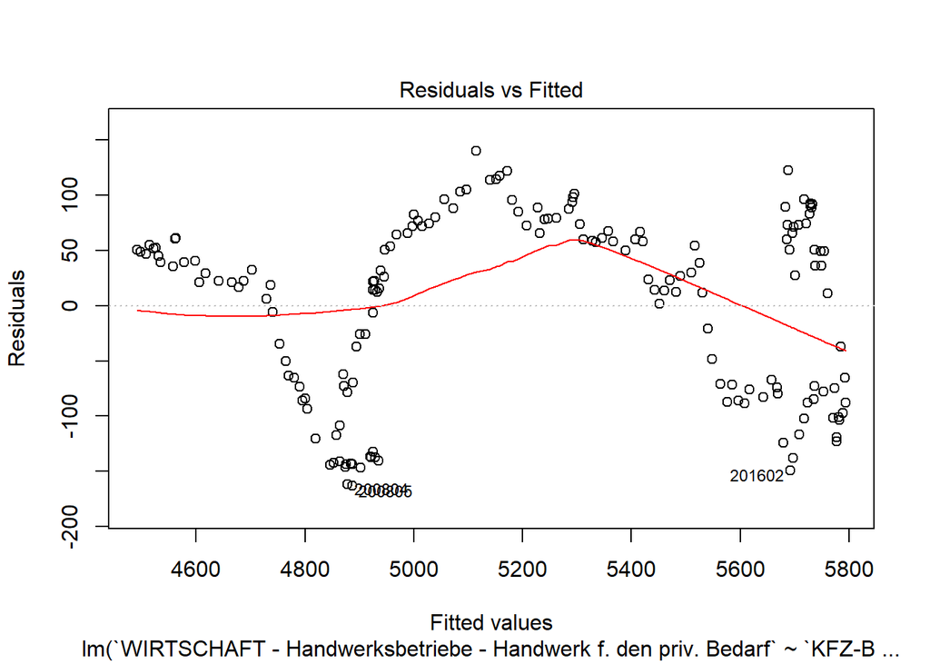

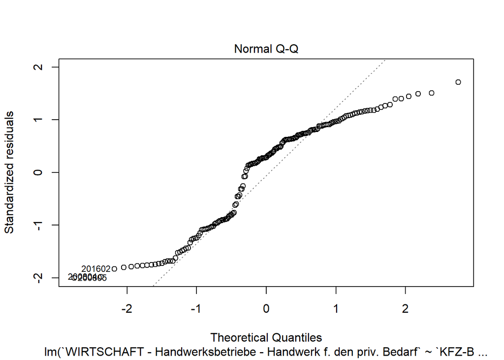

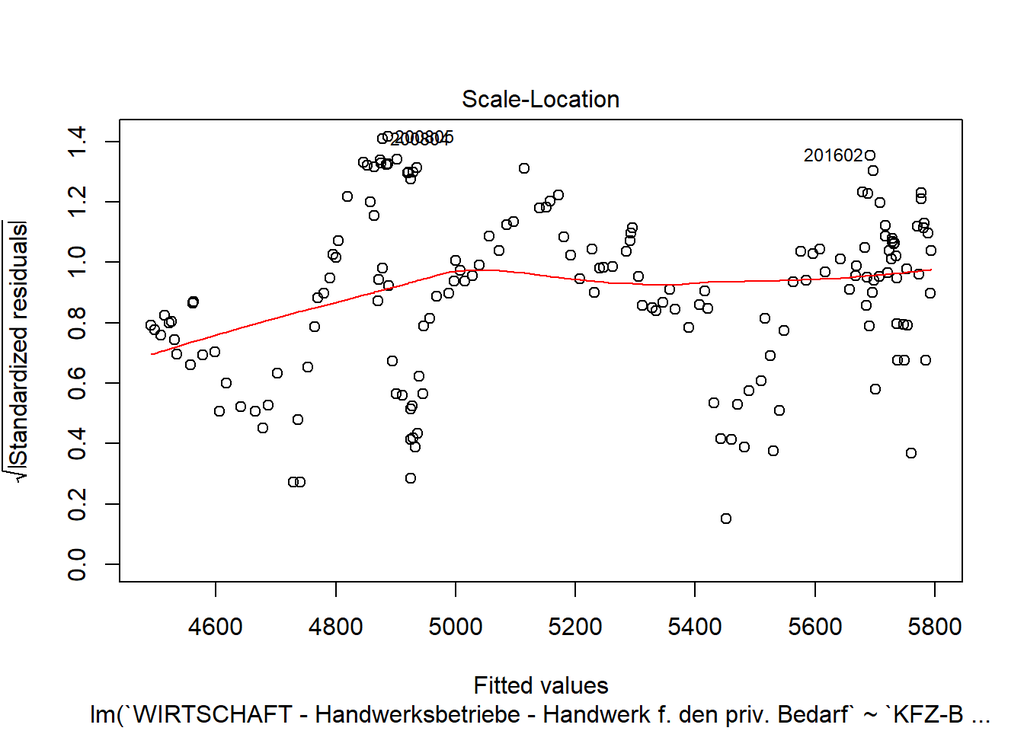

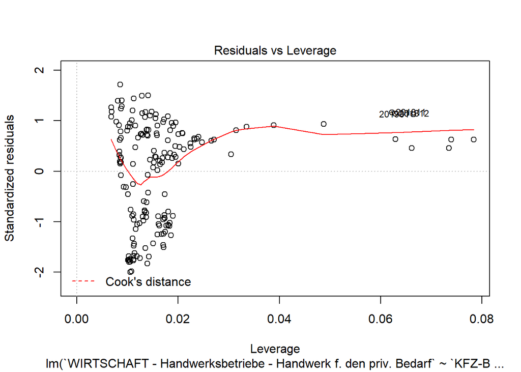

```r
plot(model.lm)
```

:)